# Presentación seminario slides

**PAP:** Programa de modelación matemática para el desarrollo de planes y proyectos de negocio.

**CHANGE POINT DETECTION**

**Integrante 1** Carlos Alfonso Barboza Espinoza

**Integrante 2** Jaime Eduardo Vázquez Guzmán

**CONTEXTUALIZACIÓN**

**¿Qué es?**

Es un análisis estadistico, su función

es detectar los puntos en donde el proceso

estocástico o la serie de tiempo cambia.

Serie de tiempo.

Es una secuencia infinita de datos.

S = {x1, x2, …, xn}

Serie de tiempo estacionaria.

La media de la serie es lineal durante todo el tiempo.(Constante)

μt = E(xt)

**Función de costo**

**$$C(yI)=|I|log(μI)$$**

"C" es la función de costo.

"I" es el intérvalo.

"y" es la secuencia.

"μ" es la media.

**Datos diarios del par USD/MXN.**

```python
quotesd
```

| date | Open | High | Low | Close |
| --- | --- | --- | --- | --- |
| 2014-11-07 | 13.5659 | 13.5696 | 13.4980 | 13.5493 |
| 2014-11-10 | 13.5380 | 13.6151 | 13.4975 | 13.6096 |
| 2014-11-11 | 13.5951 | 13.6165 | 13.5635 | 13.6007 |
| 2014-11-12 | 13.6031 | 13.6156 | 13.5400 | 13.5533 |
| 2014-11-13 | 13.5555 | 13.6379 | 13.5408 | 13.5975 |
| ... | ... | ... | ... | ... |
| 2020-10-01 | 22.0538 | 22.1086 | 21.7770 | 21.8077 |
| 2020-10-02 | 21.8098 | 22.0633 | 21.5510 | 21.6097 |
| 2020-10-05 | 21.6012 | 21.6462 | 21.2946 | 21.3478 |
| 2020-10-06 | 21.3247 | 21.7631 | 21.2433 | 21.7117 |
| 2020-10-07 | 21.6866 | 21.7256 | 21.3460 | 21.4921 |

1543 rows × 4 columns

**Datos por hora del par USD/MXN.**

```python
quotes
```

| date | Open | High | Low | Close |
| --- | --- | --- | --- | --- |
| 2020-08-13 05:00:00 | 22.3501 | 22.3752 | 22.3304 | 22.3650 |
| 2020-08-13 06:00:00 | 22.3636 | 22.3664 | 22.2809 | 22.3203 |
| 2020-08-13 07:00:00 | 22.3203 | 22.3622 | 22.3060 | 22.3543 |
| 2020-08-13 08:00:00 | 22.3558 | 22.3752 | 22.3162 | 22.3268 |
| 2020-08-13 09:00:00 | 22.3269 | 22.3680 | 22.2741 | 22.2857 |
| ... | ... | ... | ... | ... |
| 2020-10-07 15:00:00 | 21.4933 | 21.5157 | 21.4430 | 21.4673 |
| 2020-10-07 16:00:00 | 21.4673 | 21.5277 | 21.4450 | 21.5123 |
| 2020-10-07 17:00:00 | 21.4890 | 21.5141 | 21.4410 | 21.4668 |
| 2020-10-07 18:00:00 | 21.4777 | 21.5280 | 21.4427 | 21.4630 |
| 2020-10-07 19:00:00 | 21.4612 | 21.4921 | 21.4612 | 21.4921 |

943 rows × 4 columns

**Tipos de change point detection.**

PELT (Pruned Exact Linear Time) .

Dynamic programming search method.

* Binary segmentation search method.

* Window-based search method.

**Ecuación segmentación binaria.**

**$$ C(y_{(1:t)})+C(y_{(t+1:n)})+ β < C(y_{(1:n)}) $$**

"C" es la función de costo.

"B" es la penalización.

"y" es la secuencia.

**Algoritmo Binary segmentation**

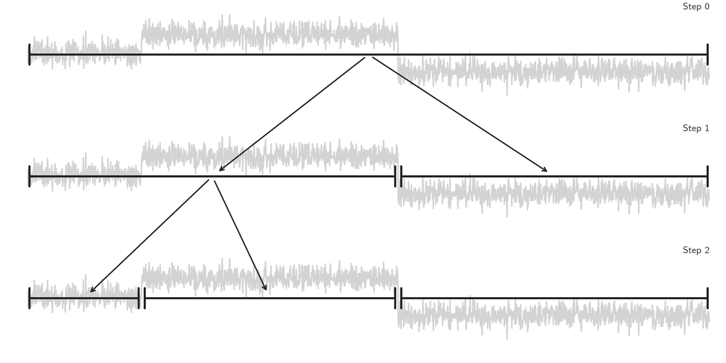

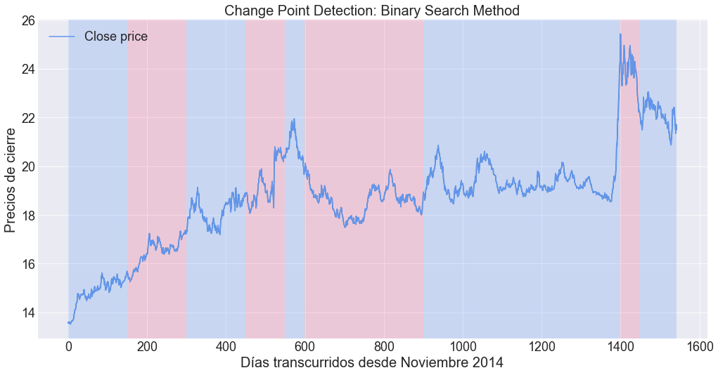

```python
model = "l2"
modelo = ruptures.Binseg(model=model, min_size=10, jump= 50).fit(Serie)
result = modelo.predict(n_bkps=8, pen=10.5)
ruptures.display(Serie, result, figsize=(14, 7))
plt.plot(Serie, label='Close price', color='cornflowerblue')
plt.title('Change Point Detection: Binary Search Method', size=20)
plt.rc('xtick', labelsize=20)
plt.rc('ytick', labelsize=20)
plt.xlabel('Días transcurridos desde Noviembre 2014',size=20)
plt.ylabel('Precios de cierre',size=20)
plt.legend(loc='upper left', fontsize=(18))
plt.show()
```

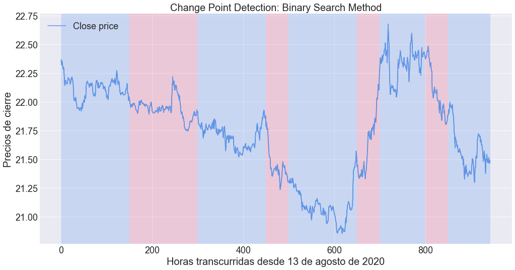

```python
modelo = ruptures.Binseg(model=model, min_size=10, jump= 50).fit(Serie2)
result = modelo.predict(n_bkps=8, pen=10.5)
ruptures.display(Serie2, result, figsize=(14, 7))
plt.plot(Serie2, label='Close price', color='cornflowerblue')
plt.title('Change Point Detection: Binary Search Method', size=20)
plt.rc('xtick', labelsize=18)
plt.rc('ytick', labelsize=18)
plt.xlabel('Horas transcurridas desde 13 de agosto de 2020',size=20)
plt.ylabel('Precios de cierre',size=20)
plt.legend(loc='upper left', fontsize=(18))
plt.show()
```

**Ecuación Window-based.**

**$$d(y_{u..v},y_{v..w})=C(y_{u..w})−C(y_{u..v})−C(y_{v..w})$$**

"C" es la función de costo.

"y" es la secuencia de datos.

"u,v,w" son los límites de la ventana.

**Algoritmo Window-based**

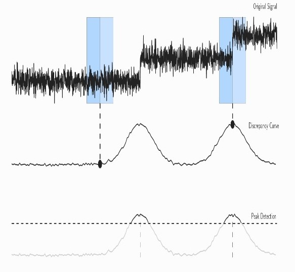

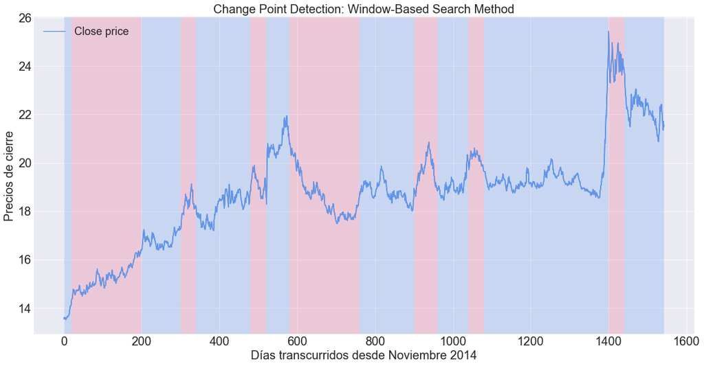

```python
model = "l2"
modelo3 = ruptures.Window(width=30, model=model, min_size=10, jump=20).fit(Serie)
my_bkps = modelo3.predict(n_bkps=14, pen= 10)
ruptures.show.display(Serie, my_bkps, figsize=(16, 8))
plt.title('Change Point Detection: Window-Based Search Method', size=20)
plt.plot(Serie, label='Close price', color='cornflowerblue')
plt.rc('xtick', labelsize=22)
plt.rc('ytick', labelsize=22)
plt.xlabel('Días transcurridos desde Noviembre 2014',size=20)
plt.ylabel('Precios de cierre',size=20)
plt.legend(loc='upper left', fontsize=(18))
plt.show()
```

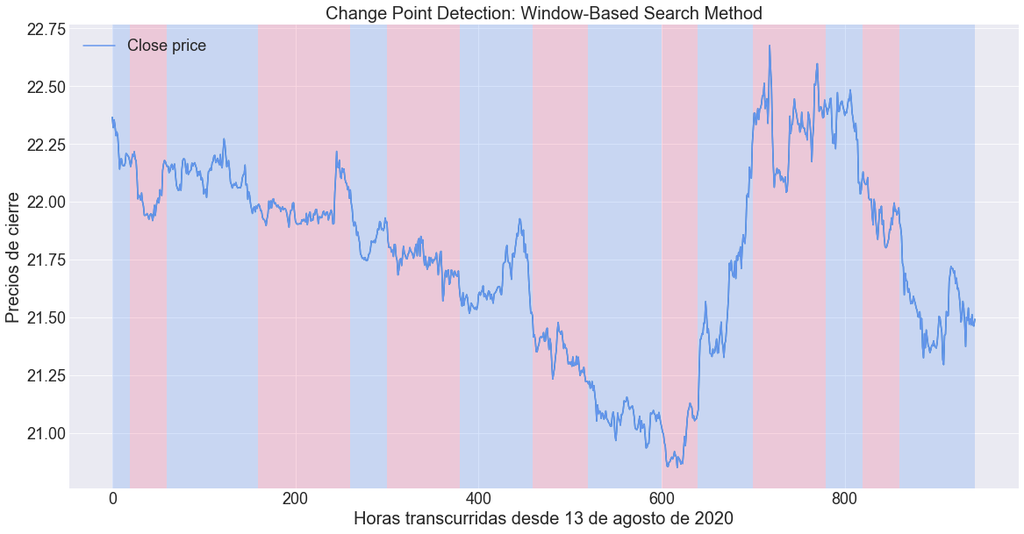

```python
modelo3 = ruptures.Window(width=30, model=model, min_size=10, jump=20).fit(Serie2)
my_bkps = modelo3.predict(n_bkps=14, pen= 10)
ruptures.show.display(Serie2, my_bkps, figsize=(16, 8))
plt.title('Change Point Detection: Window-Based Search Method', size=20)
plt.plot(Serie2, label='Close price', color='cornflowerblue')
plt.rc('xtick', labelsize=18)
plt.rc('ytick', labelsize=18)
plt.xlabel('Horas transcurridas desde 13 de agosto de 2020',size=20)
plt.ylabel('Precios de cierre',size=20)
plt.legend(loc='upper left', fontsize=(18))
plt.show()
```

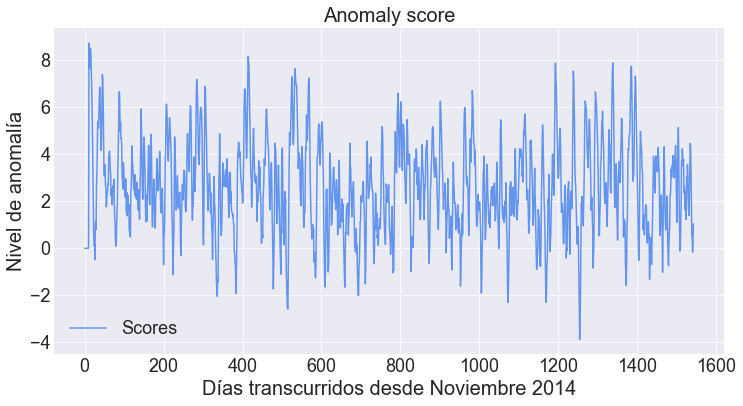

```python
plt.figure(figsize=(12, 6))
plt.title('Anomaly score', size=20)
plt.plot(scores, label='Scores', color='cornflowerblue')
plt.rc('xtick', labelsize=18)
plt.rc('ytick', labelsize=18)
plt.xlabel('Días transcurridos desde Noviembre 2014',size=20)
plt.ylabel('Nivel de anomalía',size=20)
plt.legend(loc='lower left', fontsize=(18))

plt.show()
```

**Conclusiones.**

- Se puede utilizar en series diarias, por hora e incluso por minuto.
- Con un buen modelo se garantiza el cambio de precio en su estructura.
- Mientras más datos se tengan más preciso es al momento de identificar el cambio.
- La falta de uso que se tiene de este método en temas financieros.
- Con el término de penalización en el código puedes evitar el overfitting.

**Bibliografía.**

- Truong, Charles & Oudre, Laurent & Vayatis, Nicolas (2018), A review of change point detection methods.
- Christian Rohrbeck (2017), Detection of changes in variance using binary segmentation and optimal partitioning.
- https://www.researchgate.net/publication/322221081_A_review_of_change_point_detection_methods
- https://www.lancaster.ac.uk/pg/rohrbeck/ResearchTopicI.pdf
- https://ctruong.perso.math.cnrs.fr/ruptures-docs/build/html/detection/binseg.html
- https://www.alphavantage.co/documentation/
- https://www.researchgate.net/publication/322221081_A_review_of_change_point_detection_methods
- https://techrando.com/2019/08/14/a-brief-introduction-to-change-point-detection-using-python/
- https://github.com/deepcharles/ruptures

**Repositorios.**

- https://github.com/CarlosBarbozaE/PAP/tree/Presentacion
- https://github.com/JaimeVaz